# 22100 - R for Bio Data Science

May 10, 2021

## Project Outline

1. Introduction
2. Materials and methods
3. Results and discussion

   3.1. Exploratory data analysis

   3.2. Modeling
4. Conclusion

## Introduction

## Introduction: Dataset

### COVID-19 World Vaccine Adverse Reactions

- Data from the Vaccine Adverse Event Reporting System (VAERS) created by the Food and Drug Administration (FDA) and Centers for Disease Control and Prevention (CDC)
- Contains 3 datasets:
  1. PATIENTS.CSV
  2. VACCINES.CSV
  3. SYMPTOMS.CSV
- Datasets connected by patient IDs (VAERS_ID)

## Introduction: Dataset

### COVID-19 World Vaccine Adverse Reactions

**PATIENTS.CSV**: Contains information about the individuals that received the vaccines

```
## # A tibble: 34,121 x 35
##   VAERS_ID RECVDATE  STATE AGE_YRS CAGE_YR CAGE_MO SEX   RPT_DATE   SYMPTOM_TEXT
##   <chr>    <chr>     <chr>   <dbl>   <dbl>   <dbl> <chr> <date>     <chr>
## 1 0916600  01/01/20… TX         33      33      NA F     NA         "Right side…
## 2 0916601  01/01/20… CA         73      73      NA F     NA         "Approximat…
## 3 0916602  01/01/20… WA         23      23      NA F     NA         "About 15 m…
## # … with 34,118 more rows, and 26 more variables: DIED <chr>, DATEDIED <chr>,
## #   L_THREAT <chr>, ER_VISIT <chr>, HOSPITAL <chr>, HOSPDAYS <dbl>,
## #   X_STAY <chr>, DISABLE <chr>, RECOVD <chr>, VAX_DATE <chr>,
## #   ONSET_DATE <chr>, NUMDAYS <dbl>, LAB_DATA <chr>, V_ADMINBY <chr>,
## #   V_FUNDBY <chr>, OTHER_MEDS <chr>, CUR_ILL <chr>, HISTORY <chr>,
## #   PRIOR_VAX <chr>, SPLTTYPE <chr>, FORM_VERS <dbl>, TODAYS_DATE <chr>,
## #   BIRTH_DEFECT <chr>, OFC_VISIT <chr>, ER_ED_VISIT <chr>, ALLERGIES <chr>
```

## Introduction: Dataset

### COVID-19 World Vaccine Adverse Reactions

**VACCINES.CSV**: Contains information about the received vaccine

```
## # A tibble: 34,630 x 8
##    VAERS_ID VAX_TYPE VAX_MANU         VAX_LOT VAX_DOSE_SERIES VAX_ROUTE VAX_SITE
##    <chr>    <chr>    <chr>            <chr>   <chr>           <chr>     <chr>
##  1 0916600  COVID19  "MODERNA"        037K20A 1               IM        LA
##  2 0916601  COVID19  "MODERNA"        025L20A 1               IM        RA
##  3 0916602  COVID19  "PFIZER\\BIONTE… EL1284  1               IM        LA
##  4 0916603  COVID19  "MODERNA"        unknown <NA>            <NA>      <NA>
##  5 0916604  COVID19  "MODERNA"        <NA>    1               IM        LA
##  6 0916606  COVID19  "MODERNA"        011J20A 1               IM        LA
##  7 0916607  COVID19  "MODERNA"        <NA>    <NA>            IM        LA
##  8 0916608  COVID19  "MODERNA"        <NA>    1               IM        LA
##  9 0916609  COVID19  "MODERNA"        011J20… 1               IM        LA
## 10 0916610  COVID19  "MODERNA"        <NA>    1               SYR       LA
## # … with 34,620 more rows, and 1 more variable: VAX_NAME <chr>
```

## Introduction: Dataset

### COVID-19 World Vaccine Adverse Reactions

**SYMPTOMS.CSV**: Contains information about the symptoms experienced after vaccination

```
## # A tibble: 48,110 x 11
##   VAERS_ID SYMPTOM1     SYMPTOMVERSION1 SYMPTOM2     SYMPTOMVERSION2 SYMPTOM3
##   <chr>    <chr>                  <dbl> <chr>                  <dbl> <chr>
## 1 0916600  Dysphagia               23.1 Epiglottitis            23.1 <NA>
## 2 0916601  Anxiety                 23.1 Dyspnoea                23.1 <NA>
## 3 0916602  Chest disco…            23.1 Dysphagia               23.1 Pain in ex…
## 4 0916603  Dizziness               23.1 Fatigue                 23.1 Mobility d…
## 5 0916604  Injection s…            23.1 Injection s…            23.1 Injection …
## 6 0916606  Pharyngeal …            23.1 <NA>                    NA   <NA>
## # … with 48,104 more rows, and 5 more variables: SYMPTOMVERSION3 <dbl>,
## #   SYMPTOM4 <chr>, SYMPTOMVERSION4 <dbl>, SYMPTOM5 <chr>,
## #   SYMPTOMVERSION5 <dbl>
```

## Introduction: Aim

The aim of this project is to gain insight on the adverse effects of different Covid-19 vaccines and answer questions such as:

- Do some vaccines cause more/different symptoms than others?
- Do patients with some profiles get more/different symptoms?
- Are certain symptoms correlated with death?
- Is patient profile correlated with death?
- Does taking anti-inflammatory drugs reduce the chance of having symptoms?

## Methods

## Methods: Project workflow

[figure not shown]

1. Load datasets
2. Clean datasets individually
3. Augment and merge the datasets
4. Exploratory data analysis
   - Visualizations
   - PCA
5. Modelling
   - Logistic regressions
   - Proportion testing

## Methods: Challenges and solutions

### Cleaning

- **NAs** that should be interpreted as “no” → **replace_na**(ALLERGIES = “N”)
- **Duplicated IDs** → **add_count**(VAERS_ID) **%>% filter**(n == 1) **%>% select**(-n)

### Augment

- Columns containing **long string descriptions** → Make **tidy categorical (Y/N) variables**

```
## # A tibble: 3 x 3
##   VAERS_ID OTHER_MEDS                     TAKES_ANTIINFLAMATORY
##   <chr>    <chr>                          <chr>
## 1 0916983  <NA>                           N
## 2 0916988  Ibuprofen  PM the night before Y
## 3 0916996  Clobetasol, Benadryl           N
```

- **Too many symptoms** and untidy → extract **top 20 occurring symptoms** and turn them into **tidy categorical (TRUE/FALSE) columns**

## Results and Discussion

## Exploratory Data Analysis

### Visualization

## Visualization

### Group representation: Age, sex and manufacturer

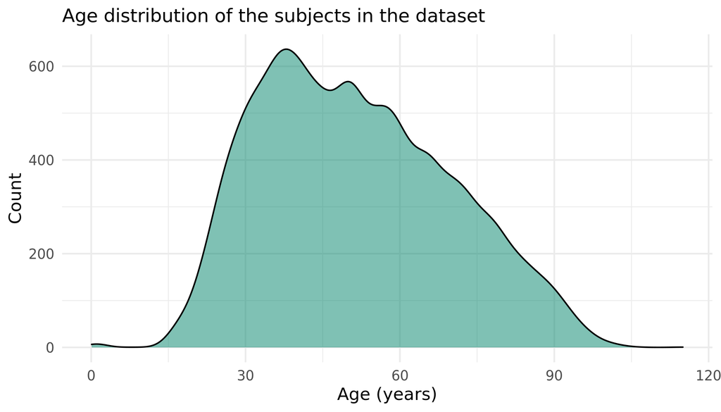

```
## # A tibble: 3 x 2
##   SEX       n
##   <chr> <int>
## 1 F     24070
## 2 M      8514
## 3 <NA>    828
```

```
## # A tibble: 3 x 2
##   VAX_MANU            n
##   <chr>           <int>
## 1 JANSSEN          1106
## 2 MODERNA         16253
## 3 PFIZER-BIONTECH 16053
```

## Visualization

### When do symptoms appear?

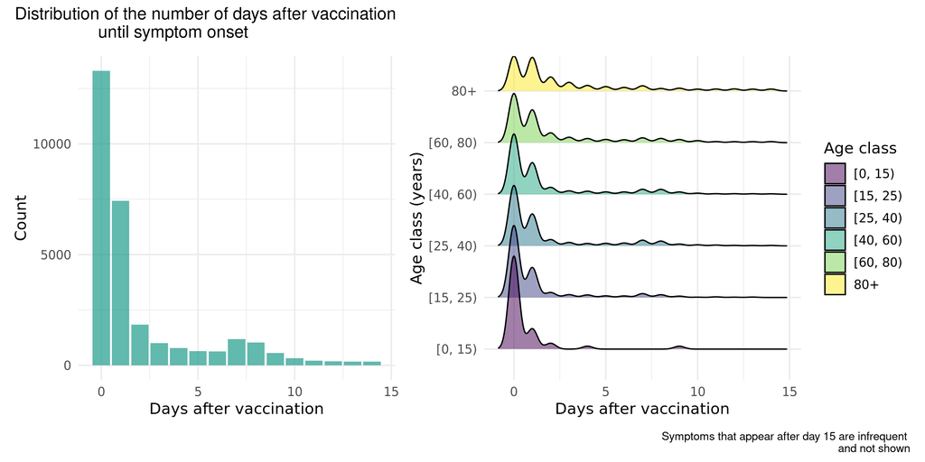

Hypothesis: two peaks corresponding to the innate and acquired immune response. Stronger innate response in younger individuals.

## Visualization

### Does age/sex impact the number of symptoms?

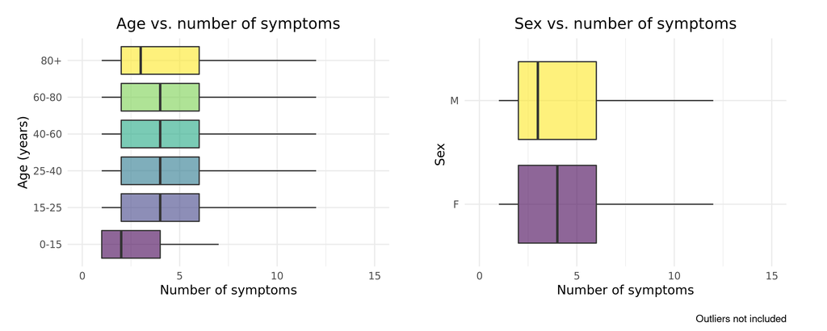

## Visualization

### Does vaccine type impact the number of symptoms?

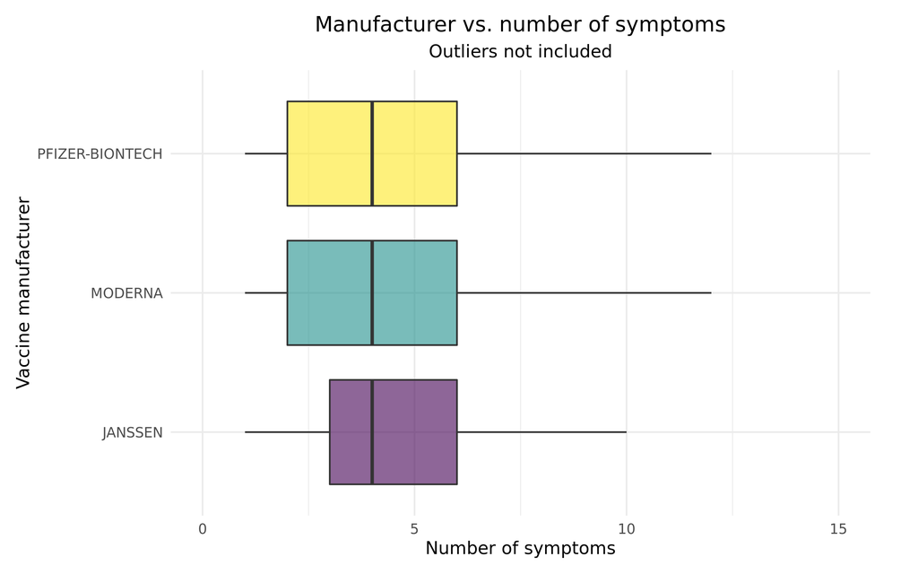

Observations: no noticeable differences

## Visualization

### Do symptoms differ among age groups?

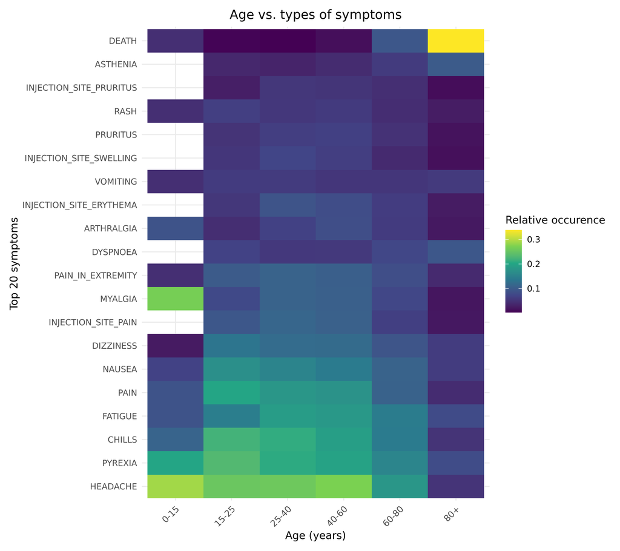

Hypothesis: symptoms associated to a strong immune response are most common in younger groups.

## Visualization

### Do symptoms differ in males and females?

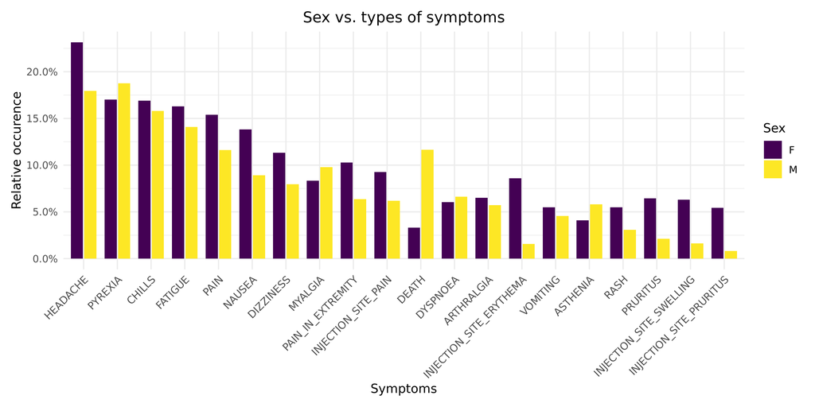

Observations: some noticeable differences, hereamongst death, more common in males.

## Visualization

### Do different vaccines cause different symptoms?

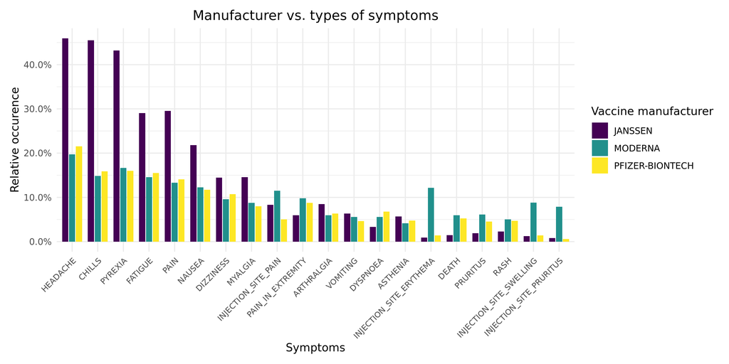

Observations: Janssen causes the most common symptoms more often (n.b. smaller sample size)

## Exploratory Data Analysis

### Principal Component Analysis

## PCA

### Do vaccine types cluster together?

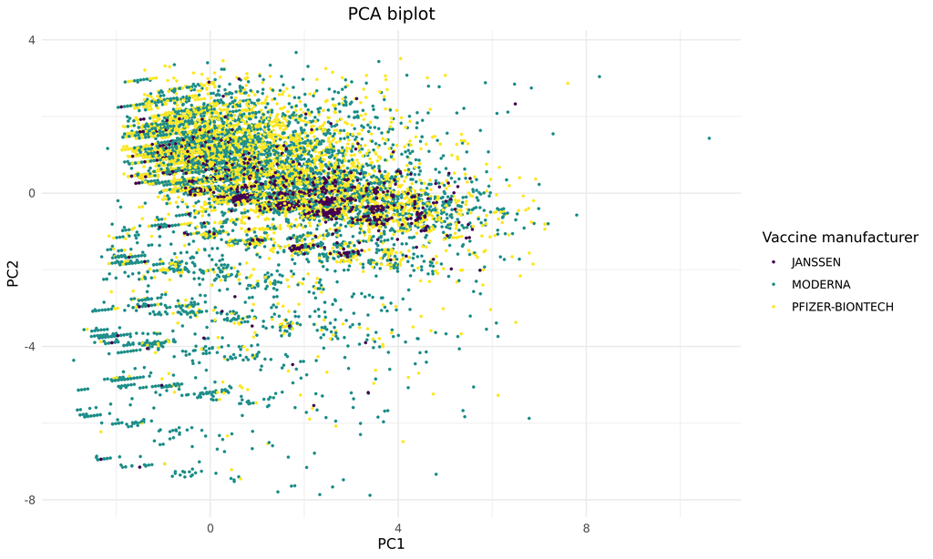

Observations: no observable clustering.

## Modelling

### Logistic Regressions

## Logistic Regression

### Is the patient’s profile correlated with death?

*glm(death ~ sex + age + allergic/not + ill/not + has/had covid/not, family = binomial)*

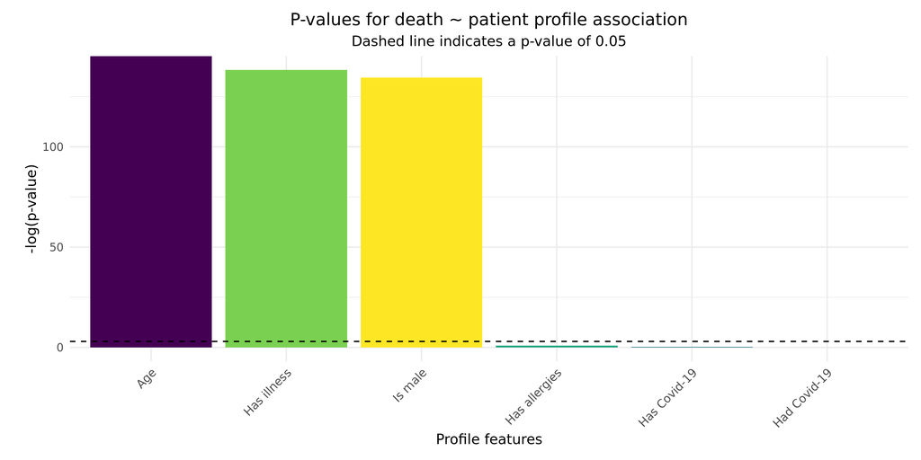

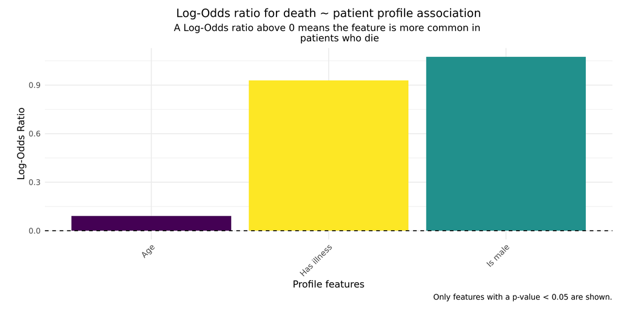

Observations: Age, illness and being male are positively correlated with death (p-value < 0.05).

## Logistic Regression

### Are some symptoms correlated with death?

*glm(death ~ symptoms, family = binomial)*

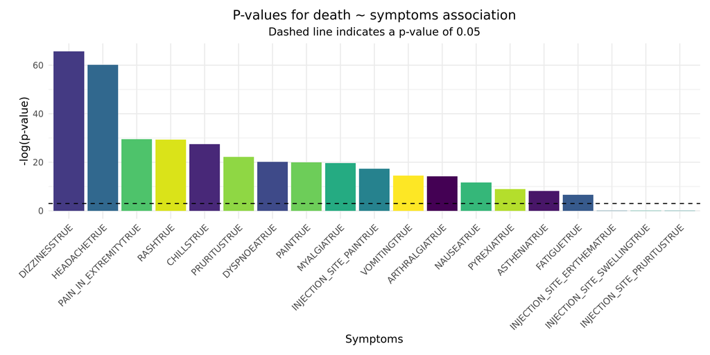

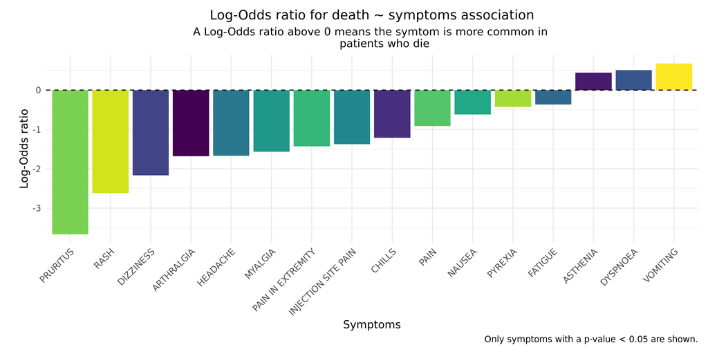

Observations: asthenia, dyspnoea and vomiting are positively correlated with death (p-value < 0.05).

## Many Logistic Regressions

### Do anti-inflammatory drugs reduce symptoms?

*glm(each symptom ~ takes anti-inflammatory/not , family = binomial)*

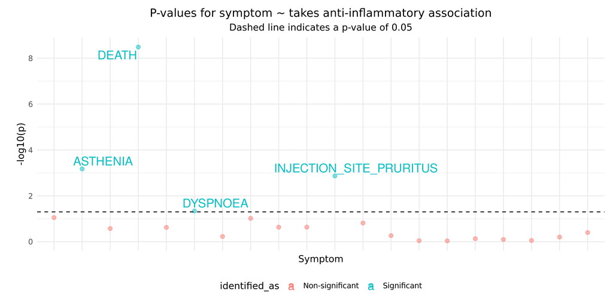

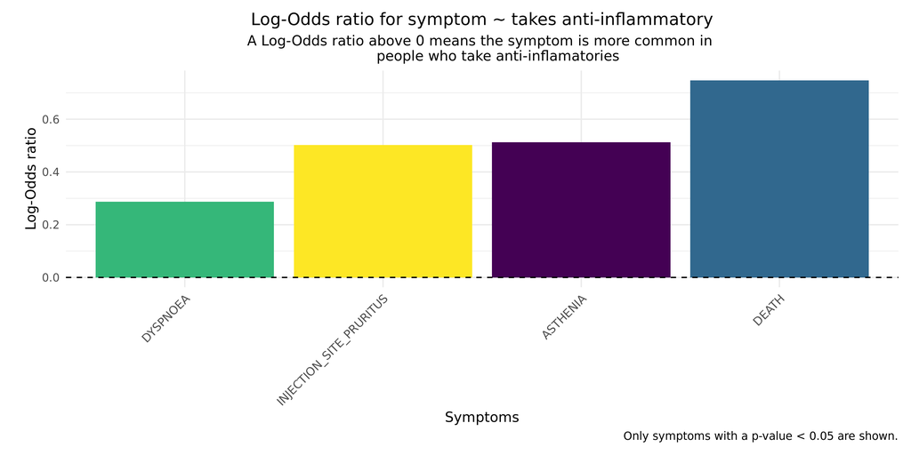

Observations: no significant reduction in symptoms (p-value < 0.05). Possible increase?

## Modelling

### Proportion tests

## Proportion tests

### Does the proportion of death differ amongst vaccine types?

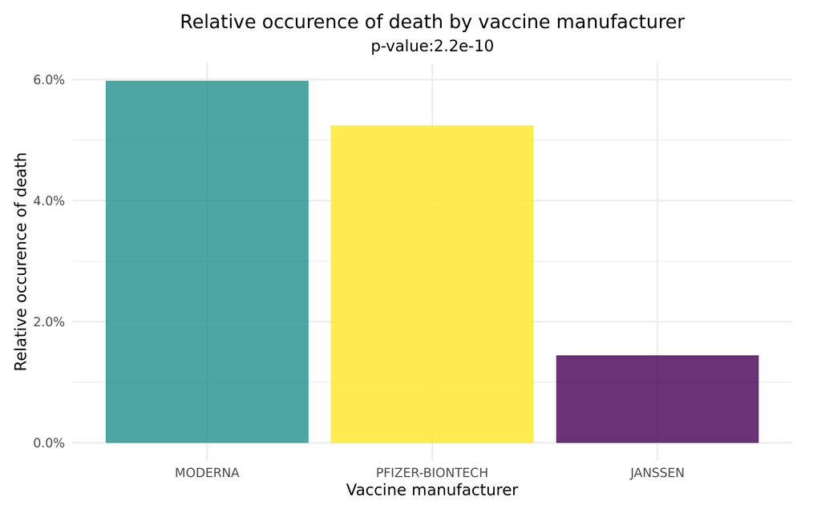

```
## # A tibble: 2 x 4
##   DIED  JANSSEN MODERNA `PFIZER-BIONTECH`
##   <chr>   <dbl>   <dbl>             <dbl>
## 1 N        1090   15281             15212
## 2 Y          16     972               841
```

Observations: there is a significant difference among vaccine types (p-value < 0.05).

## Proportion tests

### Does the proportion of death differ between males and females?

[figure not shown]

```
## # A tibble: 2 x 3
##   DIED      F     M
##   <chr> <dbl> <dbl>
## 1 N     23271  7523
## 2 Y       799   991
```

Observations: death is significantly more common in males (p-value < 0.05).

## References

Dataset: https://www.kaggle.com/ayushggarg/covid19-vaccine-adverse-reactions?select=2021VAERSSYMPTOMS.csv

Dataset user guide: https://vaers.hhs.gov/docs/VAERSDataUseGuide_November2020.pdf